# Input per bilancio di missione

Autore/Autrice

Fondazione Cariparma - Osservatorio dei dati sociali

Data di Pubblicazione

13-febbraio-2026

# Importazione dati principali

# 1° PRIORITÀ: Ridurre le disuguaglianze

> “La Fondazione si pone l’obiettivo strategico di affrontare dinamiche che influenzano le disparità e le distanze tra persone.” [DPP 2025]”

Quali sono le **dinamiche demografiche in atto** che influenzano le disuguaglianze e le distanze tra persone?

## Popolazione residente

La popolazione residente nella provincia di Parma nel 2025 (ultimo aggiornamento: 03/06/2025) è di 460.351 abitanti. Il territorio accoglie una percentuale di residenti stranieri più alta della media regionale, al cui interno, la distribuzione per età mostra una concentrazione in fasce più giovani.

### [Tbl] Popolazione residente (con % straniera)

| Popolazione residente e straniera a Parma ed Emilia-Romagna (2025) Territorio | Popolazione residente e straniera a Parma ed Emilia-Romagna (2025) Popolazione residente (2025) | Popolazione residente e straniera a Parma ed Emilia-Romagna (2025) Popolazione straniera residente (2025) | Popolazione residente e straniera a Parma ed Emilia-Romagna (2025) % popolazione straniera sul totale (2025) |
| --- | --- | --- | --- |
| Parma | 460.351 | 67.439 | 14,65 % |
| Emilia-Romagna | 4.482.977 | 564.745 | 12,60 % |

Fonte: Regione Emilia-Romagna - Statistica e Istat - Demografia in cifre, 2025

### Piramide d’età

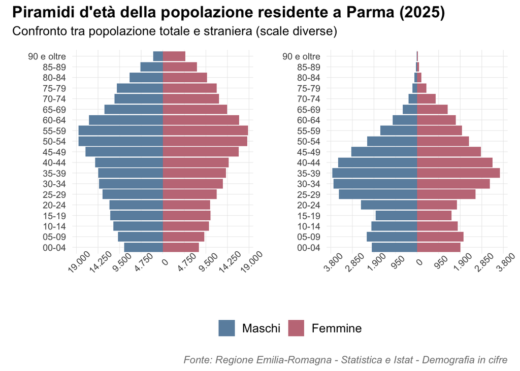

## Popolazione per 4 distretti

La popolazione residente nella provincia di Parma è suddivisa in 4 distretti sanitari, e si concentra principalmente nel distretto di Parma città, che include il capoluogo e i comuni limitrofi.

### [Tbl] Popolazione residente per distretti di Parma

| Popolazione residente per distretto sanitario (2025) Provincia | Popolazione residente per distretto sanitario (2025) Distretto | Popolazione residente per distretto sanitario (2025) Popolazione residente |
| --- | --- | --- |
| Parma | Distr. San. Valli Taro e Ceno (AUSL PR) | 43.477 |
| Parma | Distr. San. Fidenza (AUSL PR) | 105.958 |
| Parma | Distr. San. Sud Est (AUSL PR) | 78.836 |
| Parma | Distr. San. Parma (AUSL PR) | 232.080 |

Fonte: Regione Emilia-Romagna - Statistica, 2025

### Mappa popolazione residente per distretto

I distretti *Sud Est* e *Valli Taro e Ceno* sono i meno popolati e presentano il potenziale maggiore di fragilità sociale, oltre che demografica (percentuale di residenti anziani e soli, difficoltà di radicamento della popolazione straniera, opportunità di istruzione) – Cfr. **RE-R Statistica**, 2025, [*“La potenziale fragilità demografica, sociale ed economica nei comuni della regione Emilia Romagna. Anno 2023”*](https://statistica.regione.emilia-romagna.it/studi-analisi/pubblicazioni-ricerche/rapporto-mappe-potenziale-fragilita-emilia-romagna-2023).

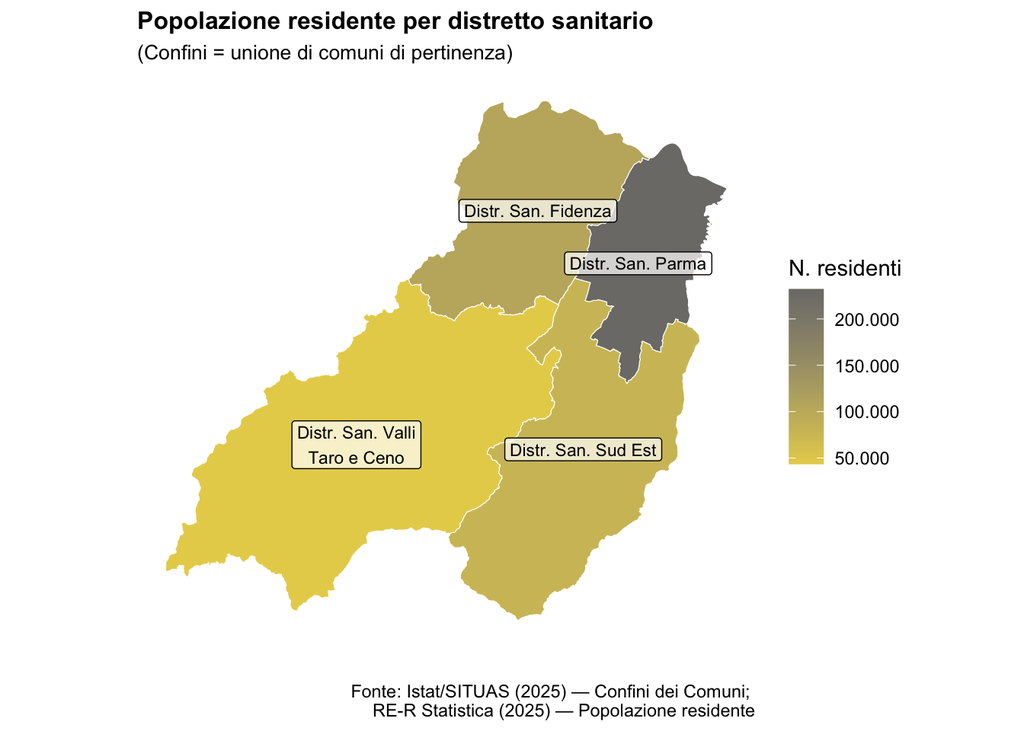

### Mappa popolazione per distetto e fasce d’età (%)

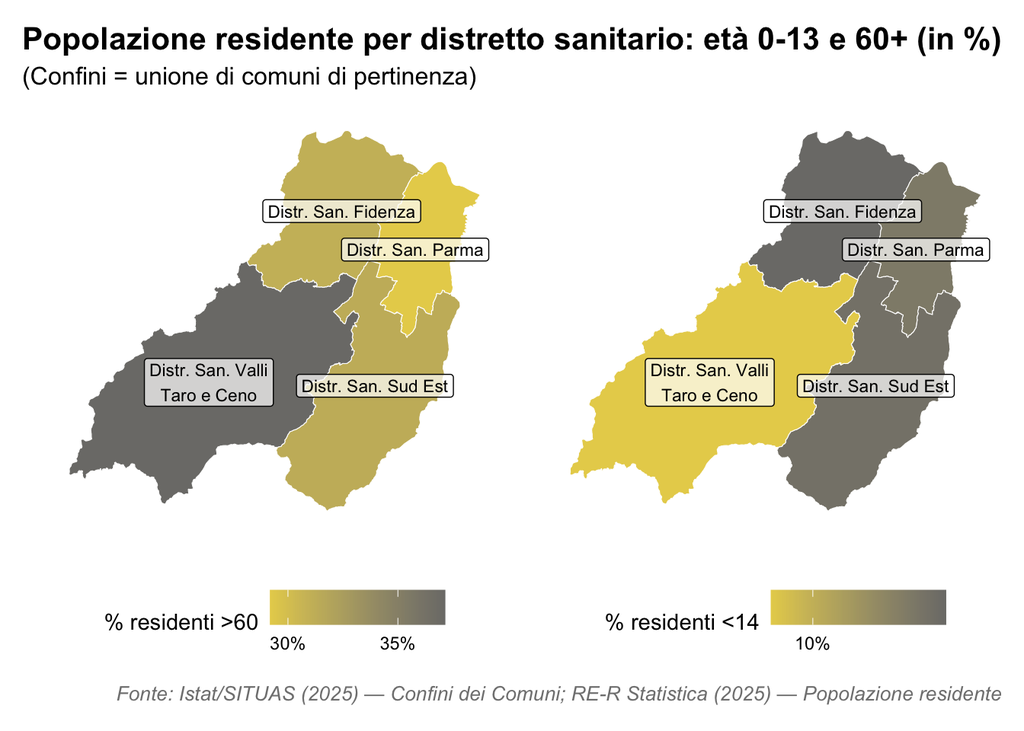

### Mappa over 65 soli per comune

Uno degli indicatori “spia” di potenziale fragilità sociale è la `percentuale di popolazione residente di 65+ anni in familglie unipersonali` (**RE-R Statistica, 2025**, con dati al 31.12.2023).

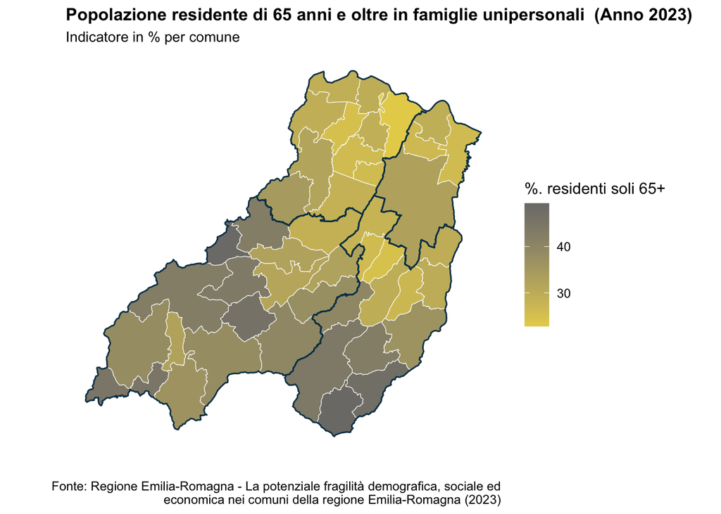

### Persone over 65 non autosufficienti

Secondo l’indagine europea sulla salute (*EHIS*), attualmente in corso di aggiornamento, na quota significativa di popolazione anziana (65+) presenta difficoltà nelle attività di cura della persona ( *ADL, Activities of Daily Living* ), sia essa moderata o grave.

Nel 2023, gli anziani non autosufficienti con gravi limitazioni erano 358.594 in Emilia-Romagna e 4.027.488 in Italia (per la prima volta sopra 4 milioni). Purtroppo a fronte di tassi di copertura del bisogno di servizi socio-sanitari altamente insufficienti e variabili a livello regionale, al netto delle diverse allocazioni/modalità di erogazione delle risorse (Fosti, Notarnicola, e Perobelli 2025).

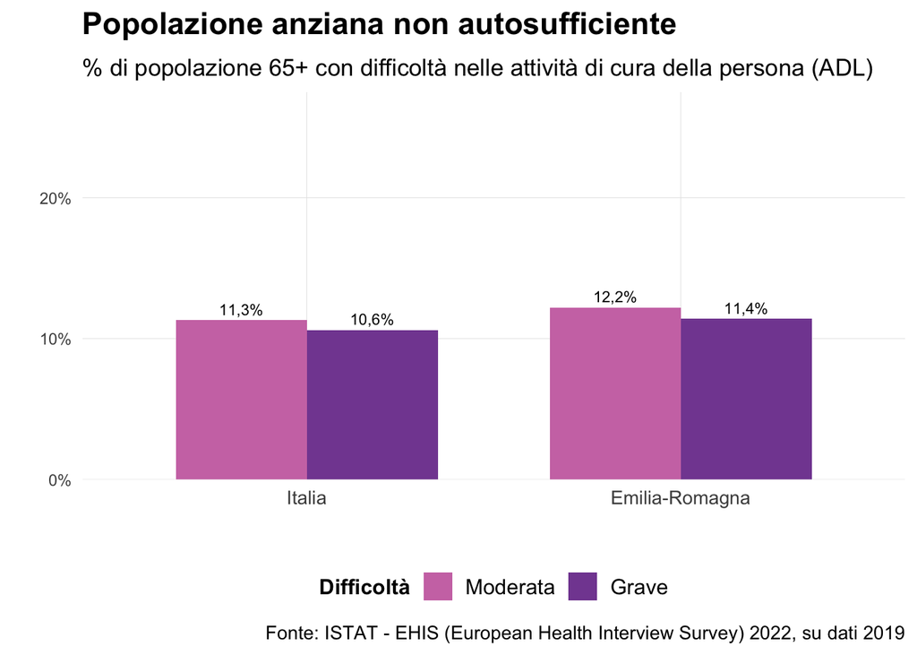

## Trend demografici a confronto

In generale, l’analisi degli indicatori demografici 2002-2025 evidenzia come il profilo demografico di Parma si distingue dalla media regionale che nazionale, specialmente per un trend di invecchiamento più contenuto e una dinamica migratoria più vivace – che contribuisce a bilanciare il deficit di natalità generalizzato.

### Popolazione Residente

#### …confronto trend flussi migratori

POCO LEGGIBILE E SCALE TROPPO DIVERSE

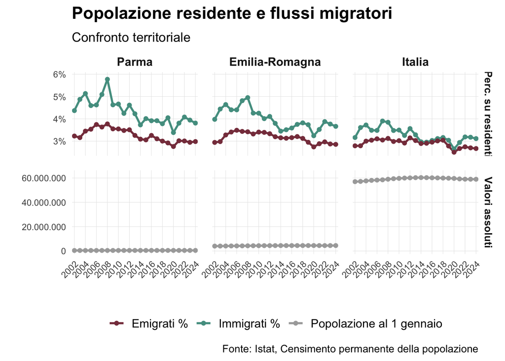

### Età media

Aumento della popolazione anziana e longevità

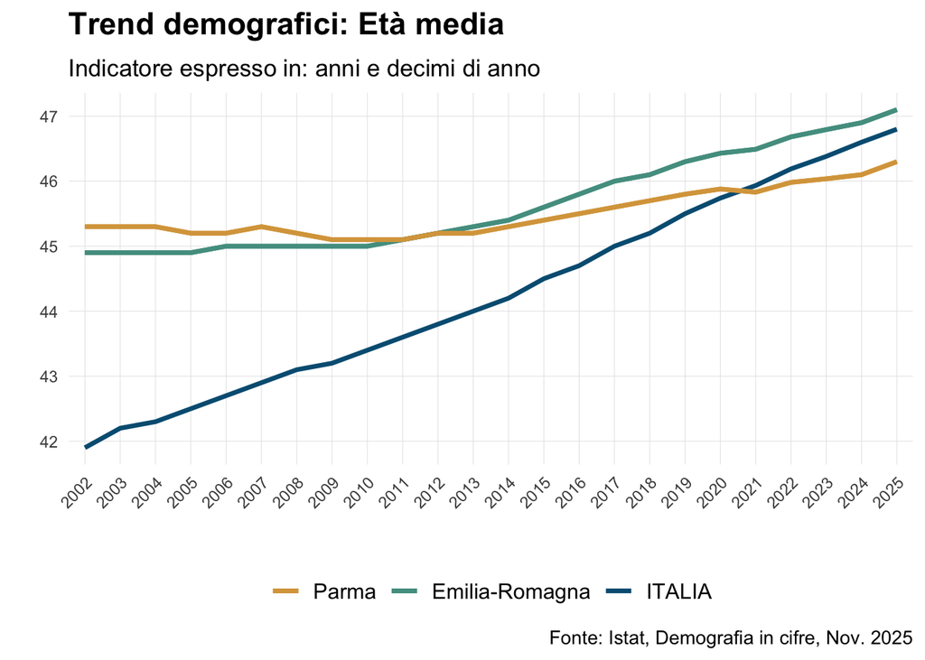

### Indice di vecchiaia

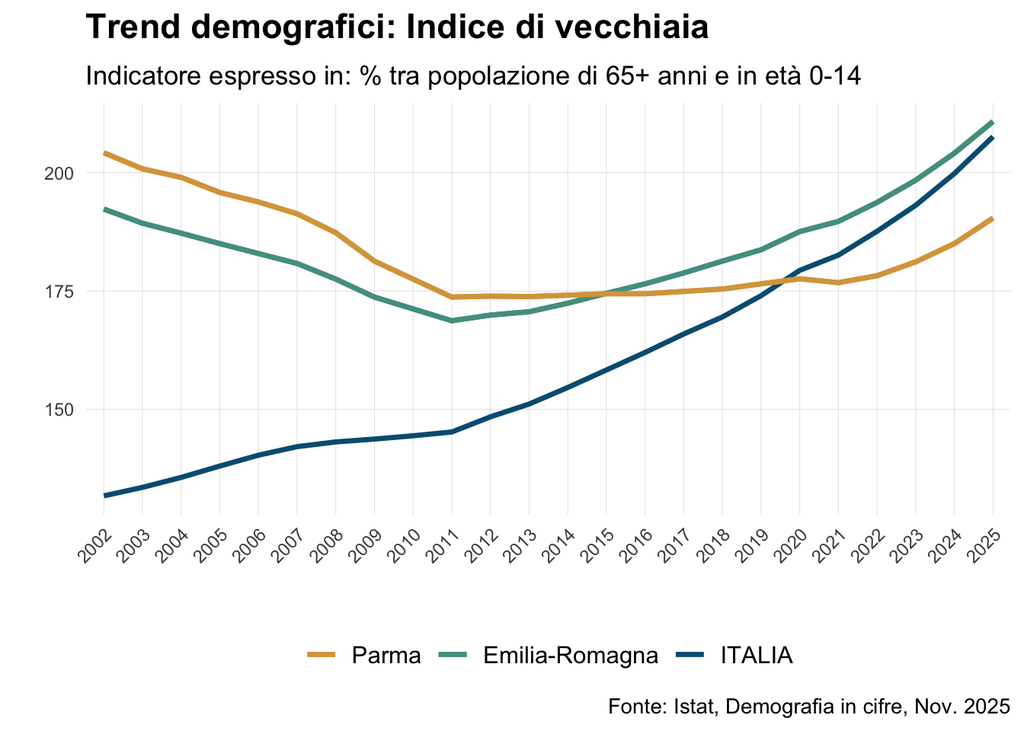

### Indice di dipendenza anziani

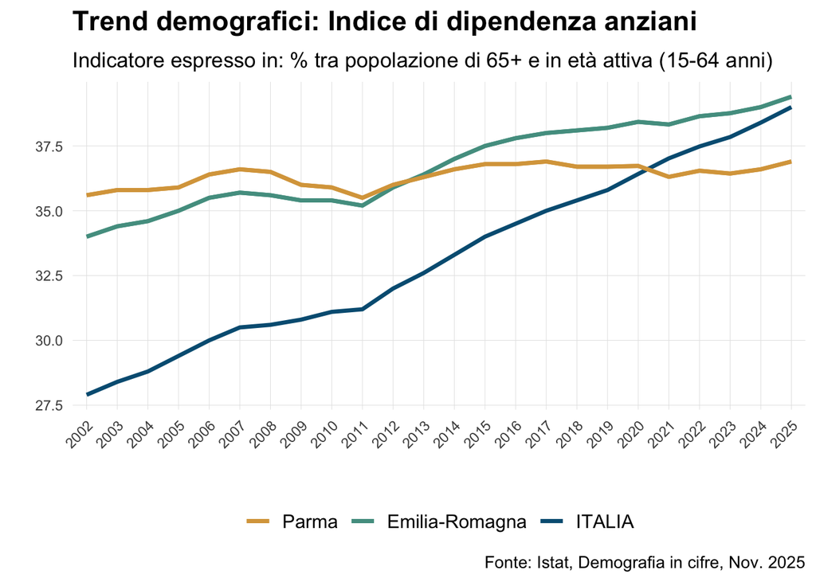

### Indice di dipendenza strutturale

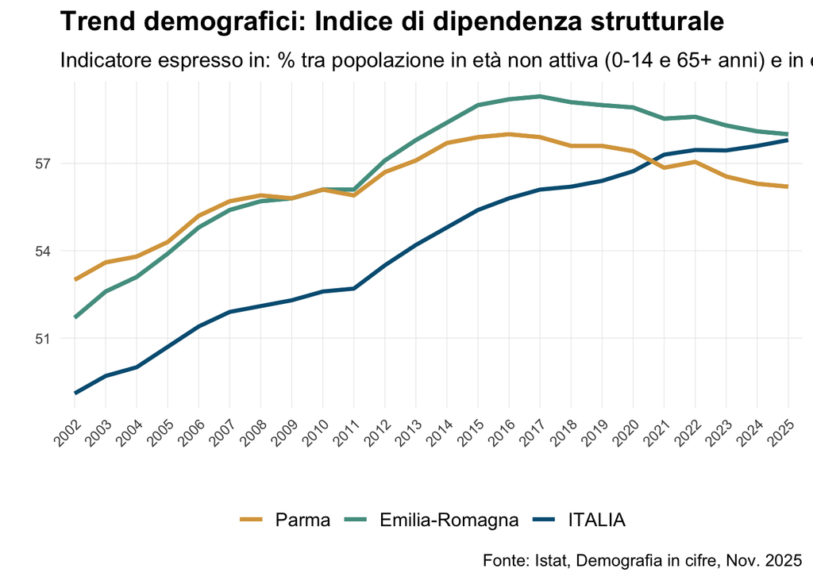

### Crescita naturale della popolazione

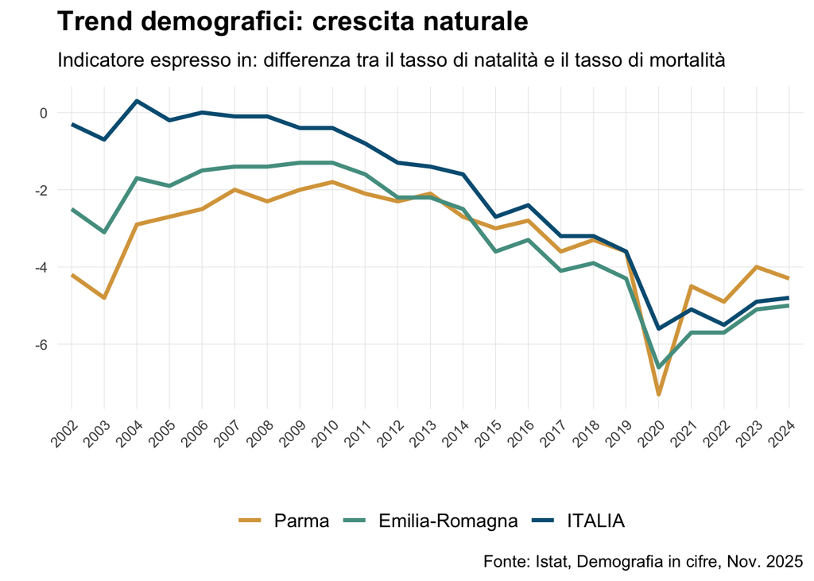

### Saldo migratorio

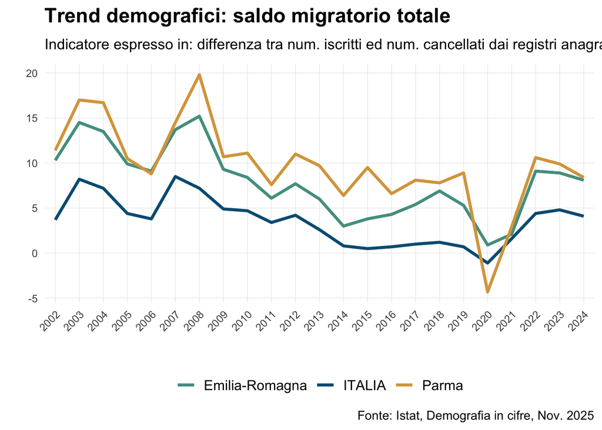

### Mobilità dei laureati

Parma ed Emilia-Romagna registrano saldi migratori positivi dei laureati (attrazione netta), mentre l’Italia nel complesso perde laureati verso l’estero, con tassi negativi stabilmente tra -2 e -8 per mille nel periodo 2019-2023.

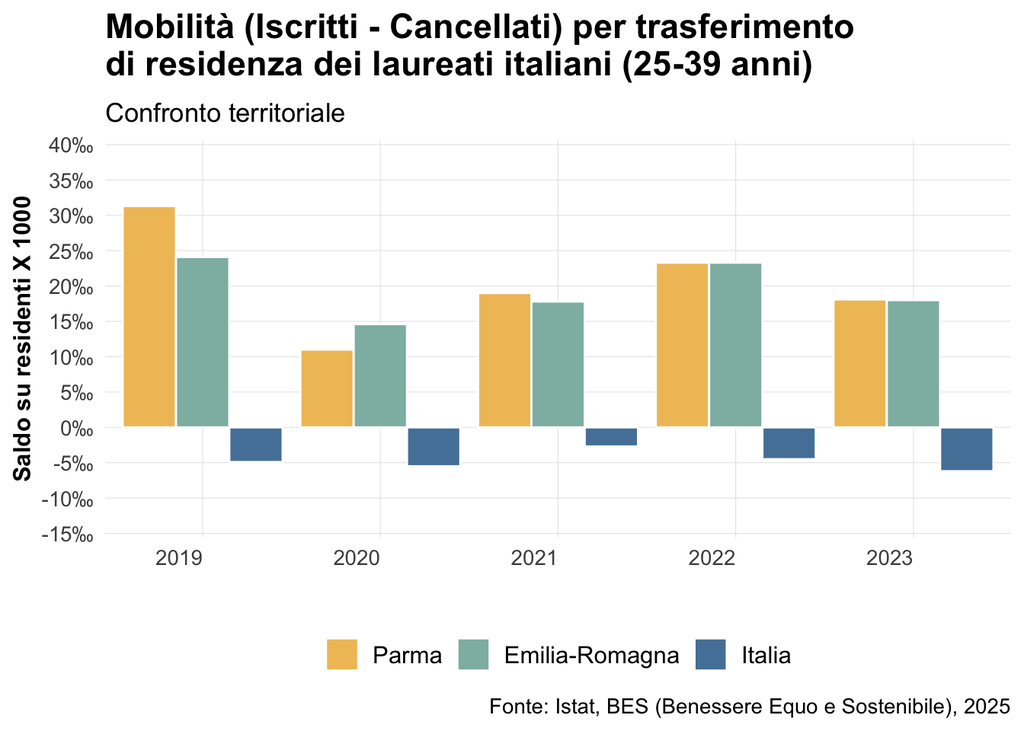

**Nota**

**Mobilità dei laureati italiani (25-39 anni)** = Tasso di migratorietà specifico dei laureati italiani di 25-39 anni (differenza tra iscritti e cancellati per trasferimento di residenza/popolazione residente *1000). Sia il numeratore che il denominatore si riferiscono ai cittadini italiani di 25-39 anni con titolo di studio terziario (laurea, AFAM, dottorato). I valori per l’Italia comprendono solo i movimenti da/per l’estero, poiché il saldo migratorio interno a livello nazionale è pari a zero; la disaggregazione territoriale comprende anche i movimenti interni.

# 2° PRIORITÀ: Rafforzare istituzioni e persone

> “La Fondazione si pone l’obiettivo strategico di lavorare per il rafforzamento di entrambe i livelli, persone e istituzioni”come crescita, formazione innovazione, e come messa in rete del proprio contributo. [DPP 2025]”

## Benessere economico delle famiglie

Da diversi anni, Istat ha sviluppato un approccio multidimensionale per misurare il **“Benessere equo e sostenibile” (Bes)**, che consente di tracciare alcune fondamentali dimensioni del benessere, ma anche potenziali fonti di disuguaglianza, osservate per diverse aggregazioni territoriali. [(Istat 2025c)]

### Reddito medio (da lavoro e pensione)

Dal punto di vista del `reddito medio disponibile pro capite` (calcolato al netto di imposte e contributi), negli anni recenti Parma si è confermata al di sopra della media regionale e nazionale.

**Nota**

Il **Reddito medio disponibile pro capite (€)** è un *aggregato di contabilità nazionale* che rappresenta il reddito medio annuo di cui una persona può disporre, al netto di imposte e contributi, tenendo conto anche di pensioni e trasferimenti pubblici.

- NB: anche se viene chiamato “reddito disponibile *lordo* pro capite” nei documenti Istat, in realta’ è già al netto delle imposte e dei contributi sociali obbligatori, quindi non è lordo in senso fiscale comune, ma nel senso della contabilita’ nazionale.
- In termini comparativi internazionali, il reddito disponibile pro capite è espresso in unità di potere d’acquisto (Purchasing Power Standard - PPS), che consente di eliminare le differenze di prezzo tra i paesi e di confrontare il potere d’acquisto effettivo dei redditi delle famiglie (+/- comparabile con **Adjusted gross disposable income of households per capita in PPS** - [Eurostat](https://ec.europa.eu/eurostat/databrowser/view/tec00113/default/table?lang=en)).

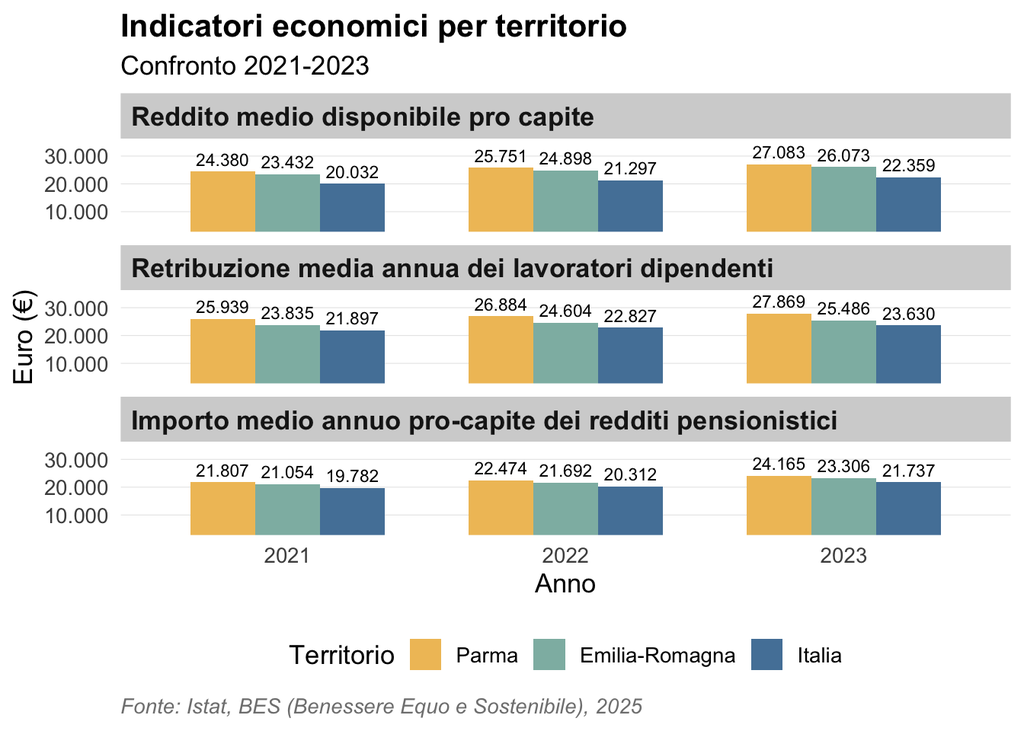

### [Tbl] Reddito medio disponibile pro capite

| Indicatori economici per territorio (€), 2021-2023 Indicatore | Indicatori economici per territorio (€), 2021-2023 Territorio | Indicatori economici per territorio (€), 2021-2023 2021 | Indicatori economici per territorio (€), 2021-2023 2022 | Indicatori economici per territorio (€), 2021-2023 2023 |
| --- | --- | --- | --- | --- |
| Reddito medio disponibile pro capite | Emilia-Romagna | 23.432 | 24.898 | 26.073 |
|  | Parma | 24.380 | 25.751 | 27.083 |
|  | Italia | 20.032 | 21.297 | 22.359 |
| Retribuzione media annua dei lavoratori dipendenti | Emilia-Romagna | 23.835 | 24.604 | 25.486 |
|  | Parma | 25.939 | 26.884 | 27.869 |
|  | Italia | 21.897 | 22.827 | 23.630 |
| Importo medio annuo pro-capite dei redditi pensionistici | Emilia-Romagna | 21.054 | 21.692 | 23.306 |
|  | Parma | 21.807 | 22.474 | 24.165 |
|  | Italia | 19.782 | 20.312 | 21.737 |

Fonte: Istat, BES (Benessere Equo e Sostenibile), 2025

#### Maschi e Femmine

Occorre però rilevare che, anche a Parma, come in Italia, permane un divario retributivo di genere significativo (questo è un dato complessivo, che andrebbe chiaramente approfondito).

| Retribuzione media per sesso (€), 2023 Indicatore | Retribuzione media per sesso (€), 2023 Territorio | Retribuzione media per sesso (€), 2023 Sesso | Retribuzione media per sesso (€), 2023 2023 |
| --- | --- | --- | --- |
| Retribuzione media annua dei lavoratori dipendenti | Parma | Femmine | 22.045,4 |
|  |  | Maschi | 32.398,9 |
|  | Italia | Femmine | 19.076,0 |
|  |  | Maschi | 27.032,5 |

Fonte: Istat, BES (Benessere Equo e Sostenibile), 2025

### Occupazione

Anche a Parma, che supera sistematicamente l’Italia nei tassi di occupazione, si riscontra un divario marcato tra i sessi (circa 20 punti percentuali per adulti, 18 per giovani, nel 2024) che rispecchia la situazione nazionale.

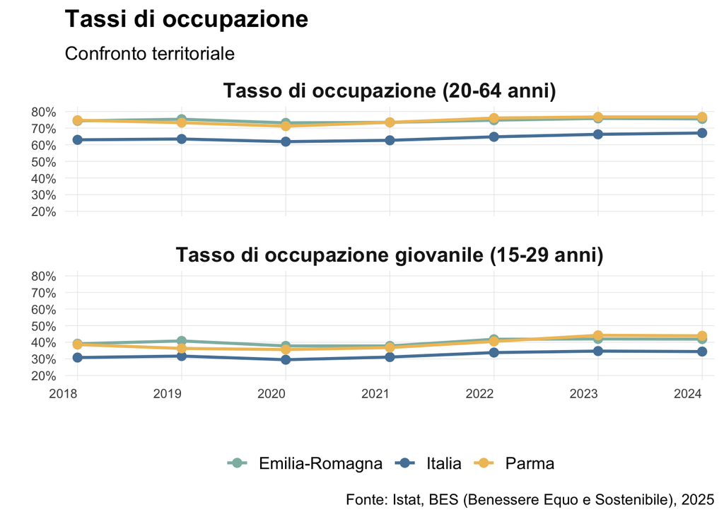

#### Maschi e femmine (2024)

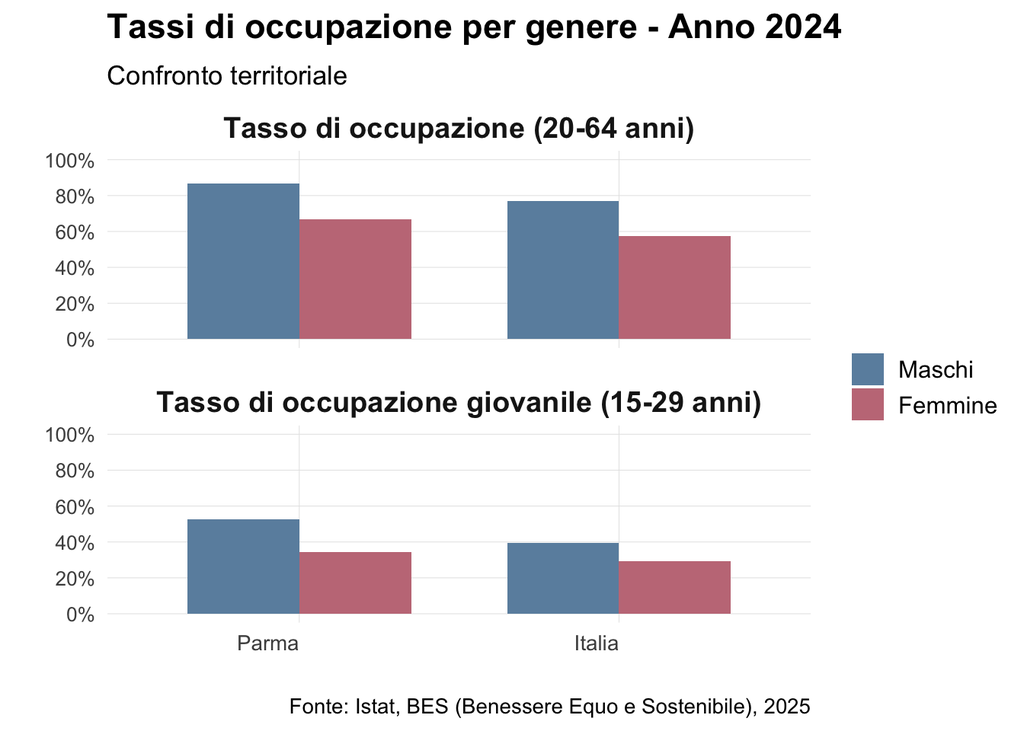

### Disoccupazione e mancata partecipazione al lavoro

In base al **tasso di mancata partecipazione al lavoro**, Parma (ed Emilia-Romagna) registrano performance significamente migliori dela media nazionale, pur mantenendo lo svantaggio per la fascia più giovane, e un divario sfavorevole per le donne.

**Nota**

Il **tasso di mancata partecipazione al lavoro** misura il *Rapporto tra la somma di disoccupati e inattivi “disponibili” (persone che non hanno cercato lavoro nelle ultime 4 settimane ma sono disponibili a lavorare), e la somma di forze lavoro (insieme di occupati e disoccupati) e inattivi “disponibili”, riferito alla popolazione tra 15 e 74 anni.* Questo dato cattura le difficoltà nel coinvolgimento della popolazione nel mercato del lavoro.

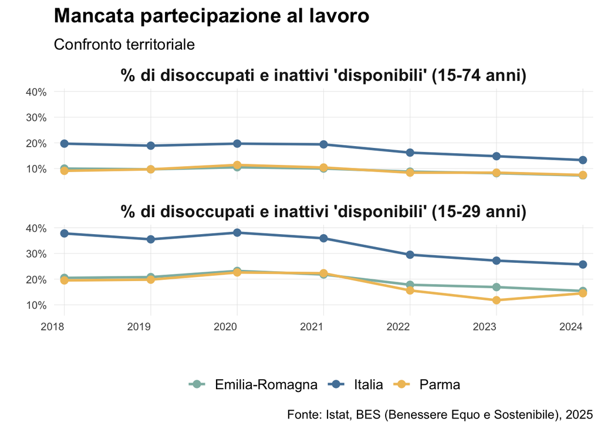

#### Maschi e femmine (al 2024)

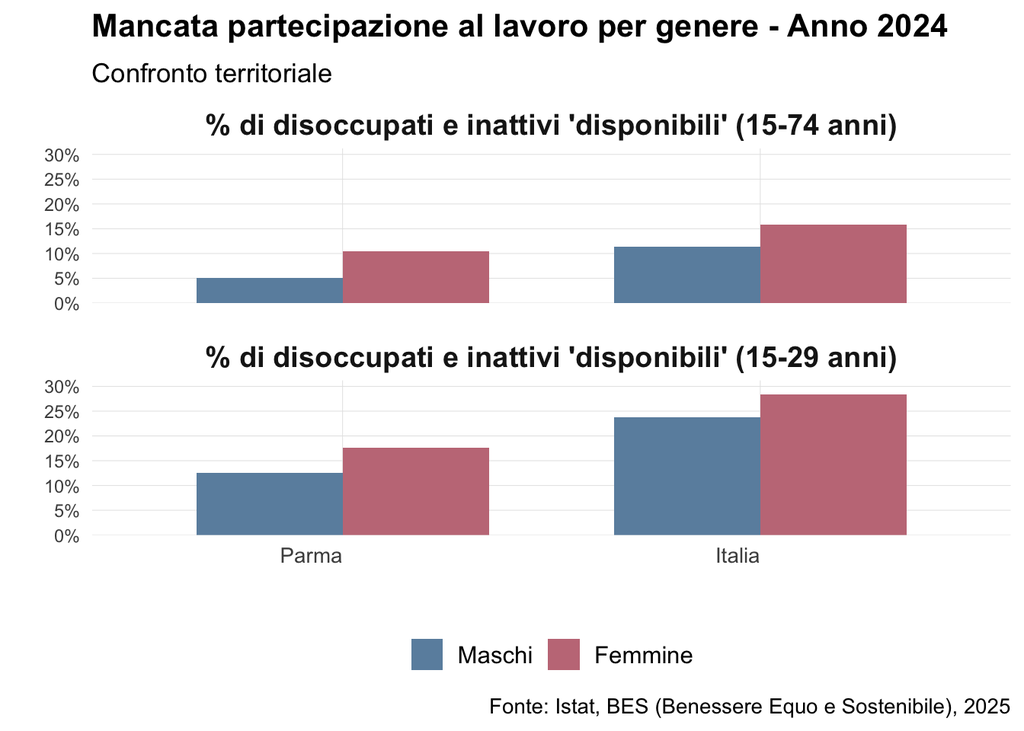

### Diplomati e laureati in Emilia-Romagna

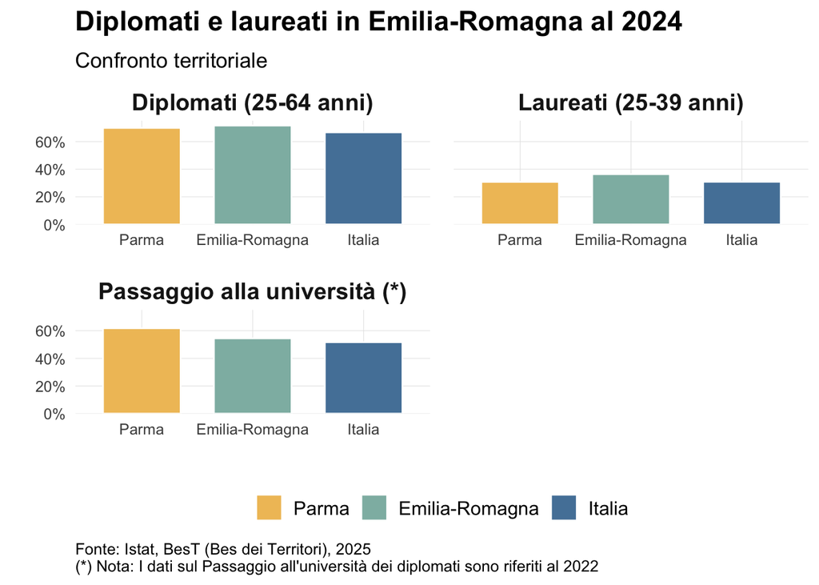

### Formazione e NEET

Parma mostra tassi NEET costantemente inferiori alla media nazionale (10,9% vs 15,2% nel 2024), abbastanza in linea con la regione. Per i laureati, Parma ha registrato un calo (da 32,4% nel 2018 a 30,8% nel 2024), posizionandosi ora sotto la media regionale (36,4%) ma in linea con quella nazionale (30,9%).

Resta piuttosto alta la partecipazione a formazione continua sul territorio – superata solo nel 2024 dalla media regionale.

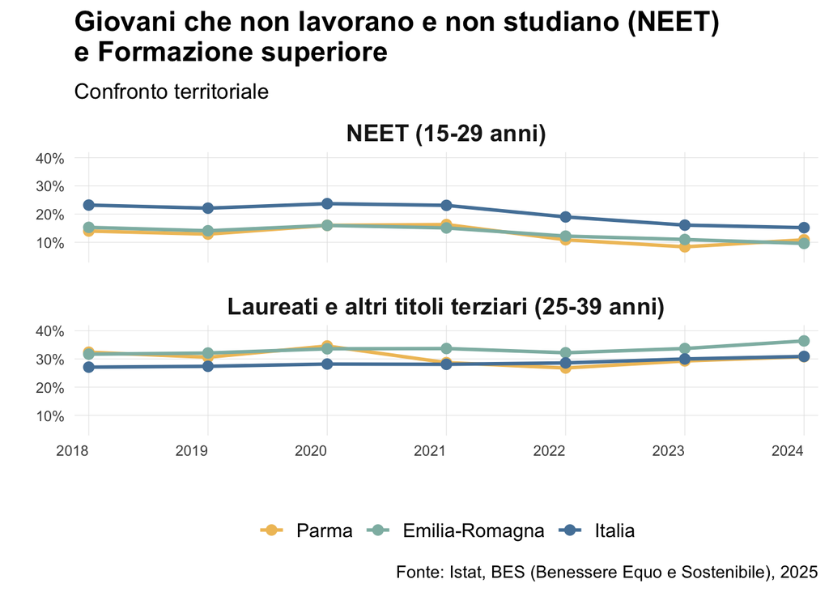

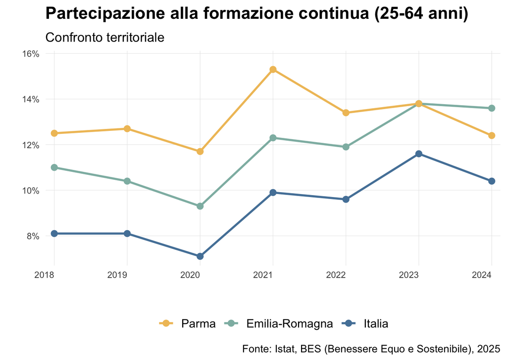

# 3° PRIORITÀ: Accompagnare le trasformazioni del territorio

> “La Fondazione si pone l’obiettivo strategico di accompagnare il territorio di parma lungo le trasformazioni e i cambiamenti inevitabili”, supportando una nuova visione strategiica e valorizzando sinergia tra obiettivi. [DPP 2025]”

## Qualità dei servizi e ambiente

QUI HO MESSO SOLO LE TABELLE PERCHE’ SONO DATI UN PO’ DISPARATI: SI POTREBBE FARSI AIUTARE E FARE DELLE INFOGRAFICHE UN PO’ PIÙ INTERESSANTI…

### [Tbl] Servizi sul territorio

Nella qualità dei servizi sul territorio, si evidenziano performance migliori a Parma rispetto alla media regionale per quasi tutti gli indicatori considerati, in particolare nella **disponibilità di verde urbano**. Sui **posti-km offerti dal trasporto pubblico locale**, Parma è al di sopra della regione, ma resta al di sotto della media nazionale.

| Qualità dei servizi (confronto territori) indicatore | Qualità dei servizi (confronto territori) unità di misura | Qualità dei servizi (confronto territori) territorio | Qualità dei servizi (confronto territori) 2018 | Qualità dei servizi (confronto territori) 2019 | Qualità dei servizi (confronto territori) 2020 | Qualità dei servizi (confronto territori) 2021 | Qualità dei servizi (confronto territori) 2022 | Qualità dei servizi (confronto territori) 2023 |
| --- | --- | --- | --- | --- | --- | --- | --- | --- |
| Copertura della rete fissa di accesso ultra veloce a internet | Valori percentuali | Parma |  |  | 42,1% | 44,5% | 52,1% | 60,0% |
|  |  | Emilia-Romagna |  |  | 26,5% | 36,1% | 52,5% | 57,6% |
|  |  | Italia |  |  | 33,7% | 44,4% | 53,7% | 59,6% |
| Comuni con servizi per le famiglie interamente online | Valori percentuali | Parma | 25,8% |  |  |  | 52,6% |  |
|  |  | Emilia-Romagna | 45,6% |  |  |  | 68,2% |  |
|  |  | Italia | 25,1% |  |  |  | 53,6% |  |
| Raccolta differenziata dei rifiuti urbani | Valori percentuali | Parma | 78,4% | 78,7% | 80,2% | 79,5% | 79,6% | 79,7% |
|  |  | Emilia-Romagna | 67,3% | 70,6% | 72,2% | 72,2% | 74,0% | 77,1% |
|  |  | Italia | 58,2% | 61,3% | 63,0% | 64,0% | 65,2% | 66,6% |
| Irregolarità del servizio elettrico | Numero medio per utente | Parma | 1,7 | 1,2 | 1,8 | 1,5 | 1,6 | 1,4 |
|  |  | Emilia-Romagna | 1,3 | 1,3 | 1,2 | 1,0 | 1,3 | 1,4 |
|  |  | Italia | 2,2 | 2,4 | 2,1 | 2,1 | 2,2 | 2,5 |
| Posti-km offerti dal Tpl | Valori per abitante | Parma | 3793 | 3818 | 3128 | 3919 | 4015 | 3956 |
|  |  | Emilia-Romagna | 2789 | 2811 | 2280 | 2807 | 2841 | 2764 |
|  |  | Italia | 4582 | 4626 | 3763 | 4731 | 4694 | 4623 |
| Disponibilità di verde urbano | M2 per abitante | Parma | 87,5 | 86,1 | 86,6 | 88,6 | 88,4 | 87,8 |
|  |  | Emilia-Romagna | 45,7 | 45,7 | 45,9 | 46,6 | 46,9 | 46,8 |
|  |  | Italia | 32,1 | 32,1 | 32,5 | 32,9 | 33,2 | 33,3 |

Fonte: Istat, BES (Benessere Equo e Sostenibile), 2025

### [Tbl] Ambiente

Nell’ambito ambientale, si evidenzia una certa disomogeneità tra Parma e l’Emilia-Romagna – come nella **dispersione idrica** in cui la media regionale sembra molto più virtuosa, o nella **concentrazione di polveri sottili** (pur molto al di sotto della media nazionale). Parma mostra performance migliori della media regionale per quel che concerne l’**impermeabilizzazione del suolo** e la **produzione di rifiuti urbani**.

| Qualità dei servizi (confronto territori) indicatore | Qualità dei servizi (confronto territori) unità di misura | Qualità dei servizi (confronto territori) territorio | Qualità dei servizi (confronto territori) 2018 | Qualità dei servizi (confronto territori) 2019 | Qualità dei servizi (confronto territori) 2020 | Qualità dei servizi (confronto territori) 2021 | Qualità dei servizi (confronto territori) 2022 | Qualità dei servizi (confronto territori) 2023 |
| --- | --- | --- | --- | --- | --- | --- | --- | --- |
| Rifiuti urbani prodotti | Kg per abitante | Parma | 586 | 596 | 601 | 598 | 600 | 596 |
|  |  | Emilia-Romagna | 661 | 664 | 639 | 641 | 633 | 641 |
|  |  | Italia | 504 | 503 | 487 | 501 | 492 | 496 |
| Dispersione da rete idrica comunale | Valori percentuali | Parma | 39,3% |  | 42,9% |  | 42,1% |  |
|  |  | Emilia-Romagna | 31,2% |  | 31,3% |  | 29,7% |  |
|  |  | Italia | 42,0% |  | 42,2% |  | 42,4% |  |
| Impermeabilizzazione del suolo da copertura artificiale | Valori percentuali | Parma | 7,49 | 7,52 | 7,53 | 7,53 | 7,57 | 7,60 |
|  |  | Emilia-Romagna | 8,76 | 8,79 | 8,81 | 8,85 | 8,88 | 8,91 |
|  |  | Italia | 7,05 | 7,07 | 7,09 | 7,11 | 7,14 | 7,16 |
| Concentrazione media annua di PM10 | Microgrammi per m3 | Parma | 32 | 30 | 30 | 30 | 30 | 27 |
|  |  | Emilia-Romagna | 9 | 9 | 9 | 9 | 9 | 9 |
|  |  | Italia | 82 | 79 | 71 | 81 | 84 | 70 |
| Concentrazione media annua di PM2.5 | Microgrammi per m3 | Parma | 19 | 17 | 18 | 15 | 16 | 15 |
|  |  | Emilia-Romagna | 9 | 9 | 9 | 9 | 9 | 9 |
|  |  | Italia | 78 | 78 | 78 | 84 | 83 | 81 |
| Energia elettrica da fonti rinnovabili | Valori percentuali | Parma | 12,6% | 12,8% | 15,1% | 14,6% | 13,2% | 16,9% |
|  |  | Emilia-Romagna | 19,7% | 20,5% | 22,1% | 20,5% | 19,6% | 21,0% |
|  |  | Italia | 34,3% | 34,9% | 37,4% | 35,1% | 30,7% | 36,9% |

Fonte: Istat, BES (Benessere Equo e Sostenibile), 2025

# Musei, monumenti e biblioteche

| Musei, gallerie, monumenti e biblioteche al 2024/2025 (confronto territori) Tipo di istituzione | Musei, gallerie, monumenti e biblioteche al 2024/2025 (confronto territori) Territorio | Musei, gallerie, monumenti e biblioteche al 2024/2025 (confronto territori) Numero totale | Musei, gallerie, monumenti e biblioteche al 2024/2025 (confronto territori) % di istituzioni a gestione pubblica |
| --- | --- | --- | --- |
| museo, galleria e/o raccolta | Parma (capoluogo) | 23 |  |
|  | Parma | 77 |  |
|  | Emilia-Romagna | 546 | 61,0 |
| area /parco archeologico | Parma (capoluogo) | 2 |  |
|  | Parma | 7 |  |
|  | Emilia-Romagna | 401 |  |
| teatri storici | Parma (capoluogo) | 4 |  |
|  | Parma | 11 |  |
|  | Emilia-Romagna | 117 |  |
| biblioteche | Parma (capoluogo) | 19 |  |
|  | Parma | 106 |  |
|  | Emilia-Romagna | 1.056 | 42,2 |

Fonte: Istat, Regione Emilia-Romagna, Sistema Bibliotecario Parmense (vari anni)

Secondo i dati “Pat-ER” (Patrimonio culturale dell’Emilia-Romagna), aggiornati al 2024/25, l’Emilia-Romagna conta 546 **musei, gallerie e collezioni**, di cui il 61% gestiti dal settore pubblico. Di questi, 77 si trovano in provincia di Parma – la seconda per numerosità. Cfr. sintesi in infografica https://bbcc.regione.emilia-romagna.it/musei-in-emilia-romagna/.

A questi si aggiungono: 401 **siti e monumenti archeologici**, di cui 7 nella provincia di Parma; 131 **castelli visitabili** in regione, di cui 22 nella provincia di Parma; più moltissimi altri luoghi d’interesse (stabilimenti termali, archeologia industriale, cimiteri monumentali, ecc.). (Regione Emilia Romagna 2026)

**NotaNota**

L’**Indagine sui musei e le istituzioni similari** è la più importante ed estesa rilevazione censuaria Istat, realizzata con il Ministero della Cultura, Regioni e Province Autonome, per mappare il sistema museale italiano. Raccoglie dati su struttura, servizi, attività, pubblico e rapporto con il territorio. Avviata nel 2012, è stata aggiornata l’ultima volta al 2023 (dati riferiti al 2022) – in allegato una presentazione dei dati più salienti per l’Emilia Romagna (RE-R Statistica e Istat 2023)

La somministrazione del prossimo questionario avverrà nel 2026 (per i dati riferiti al 2025).

# AMBITO INTERVENTO: Valorizzare l’innovazione

### Propensione alla brevettazione

Secondo dati dell’Ufficio Europeo Brevetti ( *European Patent Office*, o EPO), al 2024, l’Italia è il 6° paese dell’EU per brevetti presentati (4,853 su 68,392) e l’11° nel ranking globale, principalmente nei comparti: **Trasporti**, seguito da **Handling** e **Altre macchine speciali**. (Eurostat 2024)

Tra le regioni italiane, Lombardia, Emilia-Romagna e Veneto restano quelle più attive, contribuendo a oltre il 60% delle domande totali dall’Italia. La Lombardia si conferma leader per numero assoluto di brevetti presentate (1.468 domande, 30,2% del totale nazionale), pur con un calo del 9,7%, seguita dall’Emilia-Romagna (922, pari al 19,0% del totale italiano), che evidenzia una contrazione più contenuta (-3,8%). Se però prendiamo in considerazione il numero di brevetti in rapporto alla popolazione residente, l’Emilia-Romagna si conferma anche nel 2024 come prima regione in Italia per domande di brevetto depositate pro-capite, con 207 domande. (ART-ER 2025)

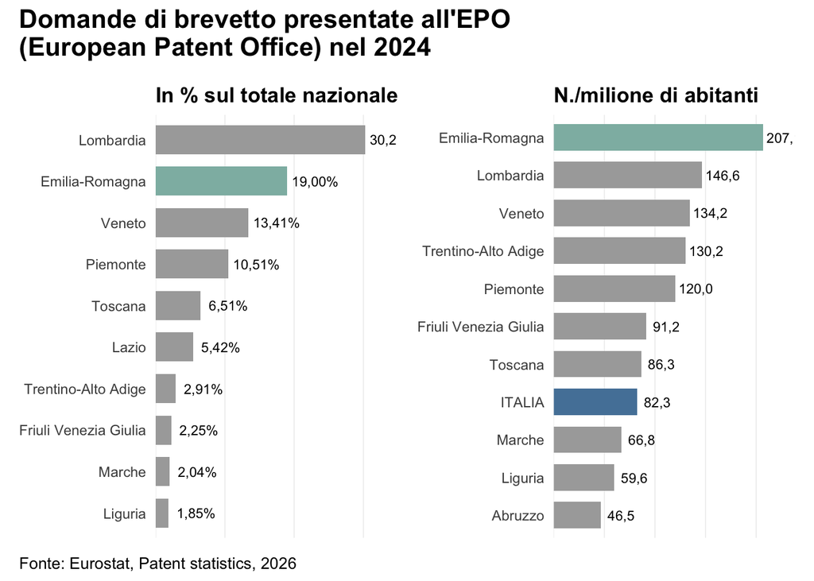

### Indicatori DESIER di innovazione digitale

L’**indice DESIER** (*Digital Economy and Society Index for European Regions*) misura le performance digitali delle regioni europee, e consente di declinare l’indice DESI sull’innovazione digitale anche nei territori dell’Emilia-Romagna (RE-R Agenda Digitale dell’Emilia-Romagna 2025). Questo strumento (realizzato nell’ambito delle attività di ADER, Agenda Digitale dell’Emilia-Romagna) consente l’analisi di 4 dimensioni di sviluppo principali che, a loro volta, combinano molti indicatori:

- `Capitale Umano` - aspetti connessi alle competenze digitali, la presenza di specialisti del settore digitale, la presenza e l’utilizzo di app, di alcuni servizi online, e social della Pubblica Amministrazione.
- `Connettività` - grado di copertura Internet con rete fissa e mobile e il relativo grado di utilizzo nel territorio.
- `Integrazione delle tecnologie digitali` - presenza sul territorio di imprese del mondo ICT, imprese innovative, start-up e finanziamenti provenienti dalla Smart Specialisation Strategy Regionale, con particolare riferimento alla digitalizzazione del mondo produttivo.
- `Servizi pubblici digitali` - vari aspetti connessi all’esistenza di open data e la possibilità di interagire online con la PA locale, o al grado di utilizzo delle Piattaforme abilitanti da parte dei cittadini e delle imprese (es. SPID, e servizi della sanità digitale online).

Questi indici mostrano una situazione abbastanza disomogenea tra Parma capoluogo (che si attesta tra i territori più avanzati della regione) e la provincia di Parma (che si posiziona in linea o al di sotto della media regionale).

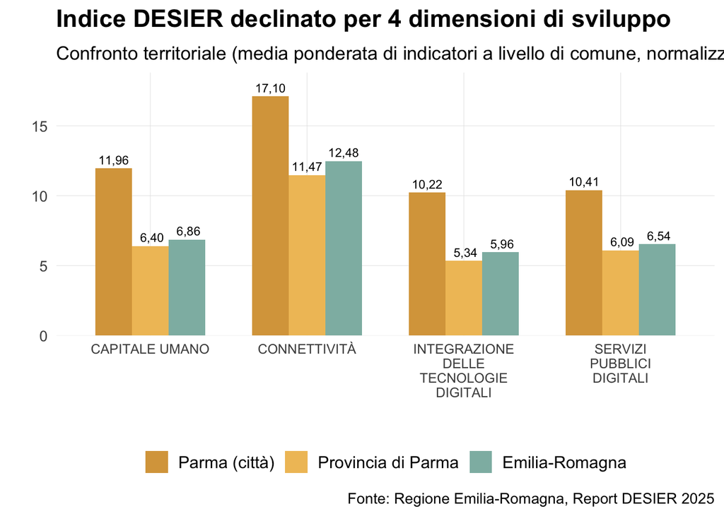

## Fonti

ART-ER. 2025. «I Brevetti Dell’European Patent Office Presentati Da Aziende e Inventori Dell’Emilia-Romagna Nel 2024».

Eurostat. 2024. «Patent Applications to the EPO by Country of Applicants and Inventors (2004 and Onwards)». European Patent Office (EPO). https://doi.org/10.2908/PAT_EP_TOT.

Fosti, Giovanni, Elisabetta Notarnicola, e Eleonora Perobelli. 2025. «Il Settore Long Term Care Tra Connessioni Interdipendenze e Necessità Di Integrazione». Osservatorio Long Term Care 7° Rapporto. Cergas Bocconi. https://cergas.unibocconi.eu/sites/default/files/media/attach/FOSTI%20NOTARNICOLA%20PEROBELLI%20il%20settore%20Long%20Term%20Care%20tra%20connessioni%20interdipendenze%20e%20necessita%20di%20integrazione%20.pdf?VersionId=Z5nirZuy8MaHSel2qnvw.uRridMGNios.

Istat. 2025a. «Demo - Demografia in Cifre». 2025. https://demo.istat.it/?l=it.

———. 2025b. «Confini delle unità amministrative a fini statistici». 13 marzo 2025. https://www.istat.it/notizia/confini-delle-unita-amministrative-a-fini-statistici-al-1-gennaio-2018-2/.

———. 2025c. «Bes Dei Territori - Emilia Romagna 2025». Comunicato territoriale. 109739. https://www.istat.it/wp-content/uploads/2025/12/BesT2025_Emilia-Romagna.pdf.

Regione Emilia Romagna. 2026. «Patrimonio Culturale Dell’Emilia-Romagna». 2026. https://bbcc.regione.emilia-romagna.it/pater/search.do?type=m&option(OGTD)=strict&value(OGTD)=Musei&fakesearch=Musei.

RE-R Agenda Digitale dell’Emilia-Romagna. 2025. «A spasso con DESIER: le performance di innovazione digitale del Comune di Parma». https://digitale.regione.emilia-romagna.it/notizie/2025/maggio/a-spasso-con-desier-le-performance-di-innovazione-digitale-del-comune-di-parma.

RE-R Statistica. 2024. «Popolazione residente per sesso, età e territorio». 20 settembre 2024. https://statistica.regione.emilia-romagna.it/dati/statistica-self-service/popolazione/popolazione-per-eta-e-sesso.

———. 2025. «La potenziale fragilità demografica, sociale ed economica nei comuni dell’Emilia-Romagna nel 2023». 18 luglio 2025. https://statistica.regione.emilia-romagna.it/studi-analisi/2025/mappe-potenziale-fragilita-emilia-romagna-2023.

RE-R Statistica, e Istat. 2023. «Visualizzazione dati sui musei e le istituzioni similari in Emilia-Romagna». Rappresentazioni grafiche di dati. https://statistica.regione.emilia-romagna.it/dati/rappresentazioni-grafiche-dati/visualizzazione-musei-emilia-romagna.

Sistema Bibliotecario Parmense. 2026. «OPAC - Catalogo delle biblioteche». 2026. https://biblioteche.parma.it/SebinaOpac/page/advanced.